# GEUC 4011 Data Analysis

ZHANG Haoxiang OP

2022-11-25

# Initialization

We only use all valid data. After cleaning the useless variables. `raw` will be the raw data.

|  | 性别 | 学历 | 年级 | 院系 | 家乡 | 是否经历过隔离...封城 | 隔离...封城.总天数 | 疫情期间各公司裁员情况了解程度 | 家庭收入 | 父母是否有于体制内工作的经历 | 实习次数 | 远程实习次数 | X13.能源. | X13.原材料. | X13.工业. | X13.可选消费品. | X13.日常消费品. | X13.医疗保健. | X13.金融. | X13.信息技术. | X13.通信服务. | X13.公用事业. | X13.房地产. | 毕业后薪资预期 | 理想工作城市 | X16.能源. | X16.原材料. | X16.工业. | X16.可选消费品. | … |
| --- | --- | --- | --- | --- | --- | --- | --- | --- | --- | --- | --- | --- | --- | --- | --- | --- | --- | --- | --- | --- | --- | --- | --- | --- | --- | --- | --- | --- | --- | --- |
| 1 | 1 | 2 | 2 | 8 | 江苏 | 2 | 14 | 4 | 4 | 1 | 1 | 0 | 0 | 0 | 0 | 0 | 0 | 0 | 0 | 0 | 0 | 0 | 0 | 2 | 江苏 | 0 | 0 | 0 | 0 | … |
| 2 | 1 | 2 | 4 | 5 | 北京 | 2 | 14 | 1 | 3 | 3 | 1 | 0 | 0 | 0 | 0 | 0 | 0 | 0 | 0 | 0 | 0 | 0 | 0 | 3 | 北京 | 0 | 0 | 0 | 0 | … |
| 3 | 4 | 2 | 2 | 7 | 辽宁 | 2 | 28 | 5 | 2 | 3 | 2 | 1 | 0 | 0 | 0 | 1 | 0 | 0 | 0 | 0 | 0 | 0 | 0 | 2 | 海外 | 0 | 0 | 0 | 1 | … |
| 4 | 2 | 2 | 2 | 7 | 黑龙江 | 2 | 100 | 4 | 1 | 2 | 1 | 0 | 0 | 0 | 0 | 0 | 0 | 0 | 0 | 0 | 0 | 0 | 0 | 2 | 北京 | 0 | 0 | 0 | 0 | … |
| 5 | 2 | 2 | 3 | 3 | 海南 | 4 | 0 | 5 | 3 | 1 | 1 | 0 | 0 | 0 | 0 | 0 | 0 | 0 | 0 | 0 | 0 | 0 | 0 | 5 | 广东 | 0 | 0 | 0 | 1 | … |
| 6 | 2 | 2 | 4 | 8 | 新疆 | 1 | 180 | 7 | 3 | 2 | 2 | 1 | 0 | 0 | 0 | 0 | 0 | 0 | 0 | 0 | 1 | 0 | 0 | 4 | 广东 | 0 | 0 | 0 | 0 | … |

## Field Explanation

**Subset**  
We divided raw data into *independent variables* and *dependent variables (response variables or y)*. *Dependent Variables* contain quantitative variables and categorical variables with pairing data. We use different Hypothesis Testing on different *dependent variables*.

`indep.var` : Subset of independent variables  
`before.var` : Subset of dependent variables before Covid19  
`after.var` : Subset of dependent variables after Covid19  
`quant.before.var` : Subset of continuous quantitative factors before Covid19  
`quant.after.var` : Subset of continuous quantitative factors after Covid19

**Independent Variables (x)**  
Independent variables will be used in linear regression step. We plan to use multiple linear regression model to prove our first hypothesis with interaction between variables.

`gender` (Dummy; Category): 1-M; 2-F; 3-Others; 4-prefer not to tell  
`degree` (Dummy; Category): 1-Junior College;  
`hometown` (Dummy; Category):  
`qnl` (Dummy Category): Experience both quarantine and lock down.  
`q` (Dummy Category): Experience quarantine only.  
`l` (Dummy Category): Experience lock down only.  
`q.l` (Dummy Category): If not experience lock down and quarantine, the value is 0. Otherwise, the value is 1.  
`qnl.time` (Quantitative): The summation of quarantine and lock down time plus 1.  
`qnl.time.log` (Quantitative): The log transformation of (summation of quarantine and lock down time plus 1).  
`decruit` (Quantitative): The acknowledgement of decruitment during COvid19.

**Dependent variables (y)**  
`further.study.before`:  
`further.study.after`:  
`quant.before.var[, 2]`: Expected stabilization of work before Covid19  
`quant.after.var[, 2]`: Expected stabilization of work after Covid19  
`reg.rv`: Difference between expected stabilization of work before and after Covid19.

# Hypothesis Testing

## Quantitative Variables Hypothesis Testing

**Logic behind the Quantitative Variables Hypothesis Testing**  
Let $X_1, X_2$ denote paired quantitative variable before and after Covid19. *E.g.$X_1$: Willingness for further study before Covid19; $X_2$: Willingness for further study after Covid19.* Let $\mu_i,\sigma^2_i$ denote the mean and variance of variable $X_i,(i=1,2)$. From the survey data, we know that $X_1, X_2$ are not normally distributed.

By Central Limit Theorem. The sampling distribution of the mean for a random variable will approximate a Normal distribution when sample size is greater than 30. The sample size $n = 80$ is actually greater than $30$. Therefore $\bar{X_i}\sim N(\mu_i,\frac{\sigma^2_i}{n})$. The sampling distribution of the mean of all quantitative dependent variables are approximately normal.

We also know that all quantitative dependent variables are in interval $[0,100]$. Each observation is independent of others. Therefore,we can use Paired Two Sample T Test. Since we do not know the exact direction for each test, we use two-tailed hypothesis.

**Hypothesis**: $H_0$: The sampling distribution of $\bar{X_1}$ is the same with the sampling distribution of $\bar{X_2}$. $H_1$: NOT the same sampling distribution.  
**Test Statistic**: Compute by the following code.  
**p-value** : Only the p-value of Expected stabilization of work $0.02$ is smaller than $\alpha=0.05$.  
**Conclusion**: Expected stabilization of work has change significantly after Covid19 under $\alpha=0.05$, i.e. `期望工作稳定程度` has significant difference. Detailed interpretation about the distribution shift is needed.  
**Limitation**: Some of the article say that Paired t-test can be used only when the difference d is normally distributed. Otherwise, it can only be checked using Shapiro-Wilk test.This is one of the ways that we can test it.

```r
head(quant.before.var)
```

|  | 毕业后深造意向程度 | 期望工作稳定程度 | 居家办公向往程度 | 体制内工作向往程度 | 知名企业向往程度 |
| --- | --- | --- | --- | --- | --- |
| 1 | 100 | 100 | 100 | 78 | 21 |
| 2 | 87 | 78 | 61 | 33 | 79 |
| 3 | 100 | 99 | 98 | 84 | 88 |
| 4 | 80 | 46 | 0 | 19 | 64 |
| 5 | 78 | 60 | 50 | 30 | 80 |
| 6 | 89 | 40 | 45 | 40 | 77 |

```r
t.test(further.study.before, further.study.after, paired = TRUE, alternative = "two.sided")
```

```
##
##  Paired t-test
##
## data:  further.study.before and further.study.after
## t = 0.86117, df = 79, p-value = 0.3917
## alternative hypothesis: true mean difference is not equal to 0
## 95 percent confidence interval:
##  -2.065329  5.215329
## sample estimates:
## mean difference
##           1.575
```

```r
t.test(quant.before.var[, 2], quant.after.var[, 2], paired = TRUE, alternative = "two.sided")
```

```
##
##  Paired t-test
##
## data:  quant.before.var[, 2] and quant.after.var[, 2]
## t = -2.2763, df = 79, p-value = 0.02554
## alternative hypothesis: true mean difference is not equal to 0
## 95 percent confidence interval:
##  -7.2400244 -0.4849756
## sample estimates:
## mean difference
##         -3.8625
```

```r
t.test(quant.before.var[, 3], quant.after.var[, 3], paired = TRUE, alternative = "two.sided")
```

```
##
##  Paired t-test
##
## data:  quant.before.var[, 3] and quant.after.var[, 3]
## t = -0.34368, df = 79, p-value = 0.732
## alternative hypothesis: true mean difference is not equal to 0
## 95 percent confidence interval:
##  -5.603022  3.953022
## sample estimates:
## mean difference
##          -0.825
```

```r
t.test(quant.before.var[, 4], quant.after.var[, 4], paired = TRUE, alternative = "two.sided")
```

```
##
##  Paired t-test
##
## data:  quant.before.var[, 4] and quant.after.var[, 4]
## t = -1.8569, df = 79, p-value = 0.06705
## alternative hypothesis: true mean difference is not equal to 0
## 95 percent confidence interval:
##  -9.0905052  0.3155052
## sample estimates:
## mean difference
##         -4.3875
```

```r
t.test(quant.before.var[, 5], quant.after.var[, 5], paired = TRUE, alternative = "two.sided")
```

```
##
##  Paired t-test
##
## data:  quant.before.var[, 5] and quant.after.var[, 5]
## t = -0.75449, df = 79, p-value = 0.4528
## alternative hypothesis: true mean difference is not equal to 0
## 95 percent confidence interval:
##  -4.956987  2.231987
## sample estimates:
## mean difference
##         -1.3625
```

## Categorical Variables Hypothesis Testing

### Expected Salary

**Hypothesis**: $H_0$: The expected salary after Covid19 follows the distribution of expected salary before Covid19. Or occurrence of Covid19 is independent from expected salary level. $H_1$: NOT follow hypothetical distribution, or dependent.  
**Test Statistic**: Compute by the following code.  
**p-value**: Way less than 0.05.  
**Conclusion**: Occurrence of Covid19 is not independent from expected salary level under $\alpha=0.05$. In other words, Covid19 has change the expected salary level of university students.  
**Limitation**: the accuracy of chi-squared test.

```r
a <- c(6,  0,  0,  0,  0, 2, 28,  5,  1,  0, 0,  1, 20,  1,  1, 0,  0,  4,  4,  0, 0,  0,  0,  0,  7)
a <- matrix(a, nrow = 5, byrow = T)
chisq.test(a)
```

```
##
##  Pearson's Chi-squared test
##
## data:  a
## X-squared = 194.77, df = 16, p-value < 2.2e-16
```

### Desired Job Industry

In some articles, it suggests us to use Marginal Homogeneity Test. There are two kinds of marginal homogeneity test. Therefore, since desired industry is nominal categorical variable. We might also use the same method from above to check dependency. For simplicity, we will use Chi-squared test.

In order to use Chi-squared test, I form a frequency contingency table named `career.csv` to help the calculation. Since if not form a frequency contingency table, the hypothesis testing result is completely different.

**Conclusion**: Covid19 has change the desired job industry of university students.  
**Limitation**: Whether Chi-squared test can replace marginal homogeneity test is debatable.

```r
career <- read.csv("career.csv", header = F)
chisq.test(career)
```

```
##
##  Pearson's Chi-squared test
##
## data:  career
## X-squared = 463.48, df = 100, p-value < 2.2e-16
```

### Important Factors

Same argument with Desired Job Industry.

I form a frequency contingency table named `factor.csv` to help the calculation. But the result is NA.

```r
factor <- read.csv("factor.csv", header=F)
chisq.test(factor)
```

```
##
##  Pearson's Chi-squared test
##
## data:  factor
## X-squared = NaN, df = 81, p-value = NA
```

### Desired City

Same argument with Desired Job Industry.

I form a frequency contingency table named `city.csv` to help the calculation.

**Conclusion**: Covid19 has change the desired working city of university students.

```r
city <- read.csv("city.csv", header=F)
chisq.test(city)
```

```
##
##  Pearson's Chi-squared test
##
## data:  city
## X-squared = 1111.2, df = 169, p-value < 2.2e-16
```

# Linear Regression

We find that the quantitative dependent variable expected stabilization of work has changed significantly after Covid19. To find out how each different independent variable will affect the expected stabilization of work, we will conduct linear regression to find the relationship.

**Dependent Variable / Response Variable / Y**  
We use the difference of expected stabilization of work before and after Covid19 as response variable(dependent variable or y), and all the independent variables as explanatory variables(terms or x).

**Explanatory Variable / Term / Predictor / X**  
Covid19 is the explanatory variable. Therefore, we can construct terms including `是否经历过隔离/封城`, `隔离封城总天数`, `疫情期间各公司裁员情况了解程度`. However, there might exist multicollinearity. We need to distinguish active terms and inactive terms.

The distribution of (`是否经历过隔离/封城`+1) vs (abs(`期望工作稳定程度`)+1) is positive and highly right-skewed. For scale matching, we use log transformation to transform the data.

**Moderator**  
The other variables that is not related with Covid19 is the moderators. We can use the interaction term to see the moderate effect.

## Model

`fit0`: `期望工作稳定程度`~`隔离封城总天数`  
`fit1`: `期望工作稳定程度`~`隔离或封城`  
`fit2`: `期望工作稳定程度`~`隔离封城`+`隔离`+`封城`  
`fit3`: `期望工作稳定程度`~`疫情期间各公司裁员情况了解程度` `fit4`: `期望工作稳定程度`~log(`隔离封城总天数`)  
`fit5`: `期望工作稳定程度`~log(`隔离封城总天数`)+`疫情期间各公司裁员情况了解程度`

`fit6`: log(abs(`期望工作稳定程度`)+1)~log(`隔离封城总天数`)  
`fit7`: log(abs(`期望工作稳定程度`)+1)~`疫情期间各公司裁员情况了解程度`  
`fit8`: log(abs(`期望工作稳定程度`)+1)~`隔离或封城`  
`fit11`: log(abs(`期望工作稳定程度`)+1)~log(`隔离封城总天数`)+`隔离或封城`  
`fit12`: log(abs(`期望工作稳定程度`)+1)~log(`隔离封城总天数`)+`疫情期间各公司裁员情况了解程度`+`隔离或封城`

## Basic Model Analysis

**Limitation**  
There are also so many models we can test. Significance level $\alpha = 0.1$ might be too loose.  
The data transformation might not be optimal.

```r
# reg.rv
# quant.after.var[, 2]
summary(qnl.time)
```

```
##    Min. 1st Qu.  Median    Mean 3rd Qu.    Max.
##     1.0    15.0    31.0    62.1    83.5   366.0
```

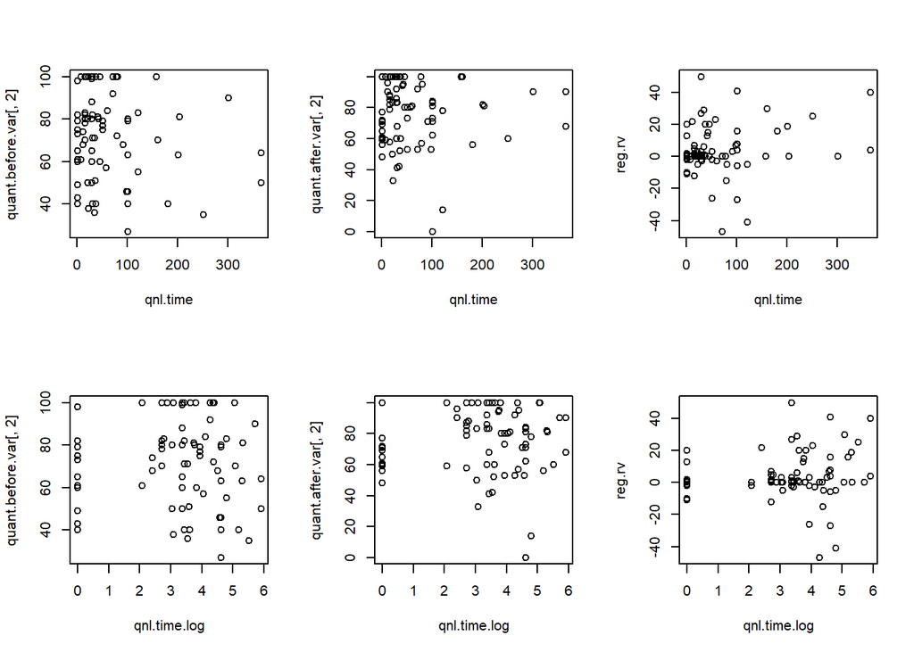

```r
par(mfrow=c(2,3))
plot(qnl.time, quant.before.var[, 2])
plot(qnl.time, quant.after.var[, 2])
plot(qnl.time, reg.rv)
plot(qnl.time.log, quant.before.var[, 2])
plot(qnl.time.log, quant.after.var[, 2])
plot(qnl.time.log, reg.rv)
```

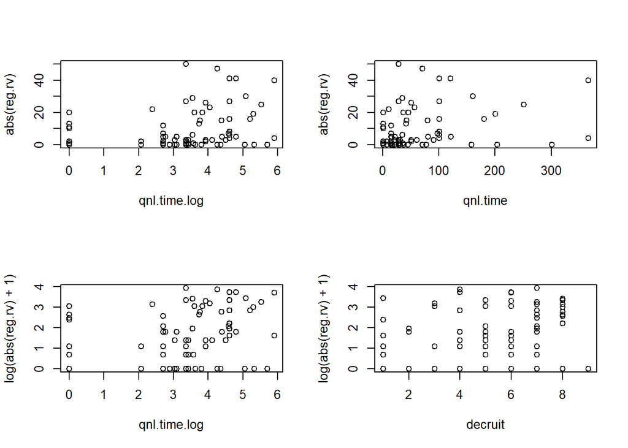

```r
par(mfrow=c(2,2))
plot(qnl.time.log, abs(reg.rv))
plot(qnl.time, abs(reg.rv))
plot(qnl.time.log, log(abs(reg.rv)+1))
plot(decruit, log(abs(reg.rv)+1))
```

```r
# head(indep.var)


fit0 <- lm(reg.rv~abs(qnl.time))
# summary(fit0)

fit1 <- lm(reg.rv~q.l)
# summary(fit1)

fit2 <- lm(reg.rv~qnl+q+l)
# summary(fit2)

fit3 <- lm(reg.rv~decruit)
# summary(fit3)

fit4 <- lm(reg.rv~qnl.time.log)
# summary(fit4)

fit5 <- lm(reg.rv~qnl.time.log + decruit)
# summary(fit5)
```

```r
fit <- lm(log(abs(reg.rv)+1)~1)
fit6 <- lm(log(abs(reg.rv)+1)~qnl.time.log)
# summary(fit6)
fit7 <- lm(log(abs(reg.rv)+1)~decruit)
summary(fit7)
```

```
##
## Call:
## lm(formula = log(abs(reg.rv) + 1) ~ decruit)
##
## Residuals:
##      Min       1Q   Median       3Q      Max
## -2.18151 -1.03644 -0.07955  0.94281  2.40536
##
## Coefficients:
##             Estimate Std. Error t value Pr(>|t|)
## (Intercept)  0.89331    0.34813   2.566   0.0122 *
## decruit      0.14313    0.06238   2.295   0.0244 *
## ---
## Signif. codes:  0 '***' 0.001 '**' 0.01 '*' 0.05 '.' 0.1 ' ' 1
##
## Residual standard error: 1.233 on 78 degrees of freedom
## Multiple R-squared:  0.06324,    Adjusted R-squared:  0.05123
## F-statistic: 5.266 on 1 and 78 DF,  p-value: 0.02444
```

```r
fit8 <- lm(log(abs(reg.rv)+1)~q.l)
# summary(fit8)
fit9 <- lm(log(abs(reg.rv)+1)~qnl.time.log+decruit)
fit10 <- lm(log(abs(reg.rv)+1)~decruit+q.l)
# summary(fit9)
# summary(fit10)
fit11 <- lm(log(abs(reg.rv)+1)~qnl.time.log+q.l)
# summary(fit11)
fit12 <- lm(log(abs(reg.rv)+1)~decruit+q.l+qnl.time.log)
fit13 <- lm(log(abs(reg.rv)+1,10)~decruit+log(qnl.time,7))
summary(fit12)
```

```
##
## Call:
## lm(formula = log(abs(reg.rv) + 1) ~ decruit + q.l + qnl.time.log)
##
## Residuals:
##     Min      1Q  Median      3Q     Max
## -2.5410 -0.8431 -0.1164  0.8694  2.2052
##
## Coefficients:
##              Estimate Std. Error t value Pr(>|t|)
## (Intercept)   0.80382    0.45304   1.774  0.08002 .
## decruit       0.14199    0.06065   2.341  0.02185 *
## q.l          -1.44734    0.69483  -2.083  0.04061 *
## qnl.time.log  0.40870    0.15096   2.707  0.00837 **
## ---
## Signif. codes:  0 '***' 0.001 '**' 0.01 '*' 0.05 '.' 0.1 ' ' 1
##
## Residual standard error: 1.192 on 76 degrees of freedom
## Multiple R-squared:  0.1465, Adjusted R-squared:  0.1128
## F-statistic: 4.348 on 3 and 76 DF,  p-value: 0.007001
```

```r
summary(fit13)
```

```
##
## Call:
## lm(formula = log(abs(reg.rv) + 1, 10) ~ decruit + log(qnl.time,
##     7))
##
## Residuals:
##     Min      1Q  Median      3Q     Max
## -0.9417 -0.4068 -0.0787  0.4601  0.9775
##
## Coefficients:
##                  Estimate Std. Error t value Pr(>|t|)
## (Intercept)       0.19630    0.18648   1.053   0.2958
## decruit           0.05826    0.02685   2.170   0.0331 *
## log(qnl.time, 7)  0.12527    0.07300   1.716   0.0902 .
## ---
## Signif. codes:  0 '***' 0.001 '**' 0.01 '*' 0.05 '.' 0.1 ' ' 1
##
## Residual standard error: 0.5289 on 77 degrees of freedom
## Multiple R-squared:  0.09775,    Adjusted R-squared:  0.07431
## F-statistic: 4.171 on 2 and 77 DF,  p-value: 0.01906
```

```r
# anova(fit10, fit11)
anova(fit7, fit12)
```

|  | Res.Df | RSS | Df | Sum of Sq | F | Pr(>F) |
| --- | --- | --- | --- | --- | --- | --- |
| 1 | 78 | 118.5811 | NA | NA | NA | NA |
| 2 | 76 | 108.0448 | 2 | 10.53638 | 3.70571 | 0.02913043 |

```r
# anova(fit, fit7)
# anova(fit, fit8)
# anova(fit7, fit9)
# anova(fit7, fit10)
```

## Moderator

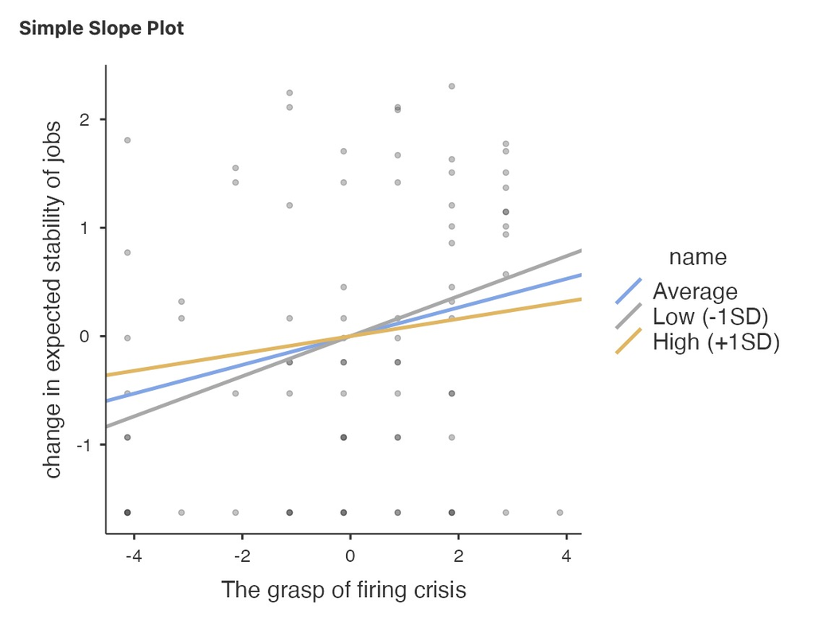

# Reference

[Marginal Homogeneity](https://online.stat.psu.edu/stat504/lesson/11/11.3/11.3.3-0)  
[Pearson’s Chi-squared Test for Count Data](https://stat.ethz.ch/R-manual/R-devel/library/stats/html/chisq.test.html)  
[How to Perform a Chi-Square Goodness of Fit Test in R](https://www.statology.org/chi-square-goodness-of-fit-test-in-r/)  
[The Chi squared tests](https://www.bmj.com/about-bmj/resources-readers/publications/statistics-square-one/8-chi-squared-tests)  
[Paired Samples T-test in R](http://www.sthda.com/english/wiki/paired-samples-t-test-in-r)  
[Paired T-Test](https://www.statisticssolutions.com/free-resources/directory-of-statistical-analyses/paired-sample-t-test/)  
[From the Central Limit Theorem to the Z- and t-distributions](https://towardsdatascience.com/introduction-tfrom-the-central-limit-theorem-to-the-z-and-t-distributions-66513defb175)  
[The Two-Sample t-Test](https://www.jmp.com/en_ch/statistics-knowledge-portal/t-test/two-sample-t-test.html)  
[Understanding the Central Limit Theorem](https://towardsdatascience.com/understanding-the-central-limit-theorem-aeb89dd0ccad)  
[Testing Significance for Non-Normal Distributions - YouTube](https://www.youtube.com/watch?v=-qTtxNPgknk)  
[Testing if two non-normal distributions are significantly different (K-S or Wilcoxon or both?)](https://stats.stackexchange.com/questions/95559/testing-if-two-non-normal-distributions-are-significantly-different-k-s-or-wilc)  
[What test is there if data is not normally distributed?](https://www.quora.com/What-test-is-there-if-data-is-not-normally-distributed)  
[6 ways to test for a Normal Distribution — which one to use?](https://towardsdatascience.com/6-ways-to-test-for-a-normal-distribution-which-one-to-use-9dcf47d8fa93)  
[McNemar, Marginal Homogeneity, Sign, Wilcoxon Tests](https://www.statisticssolutions.com/free-resources/directory-of-statistical-analyses/mcnemar-marginal-homogeneity-sign-wilcoxon-tests/)  
[Blocking in Statistics: Definition & Example](https://www.statology.org/blocking-statistics/)  
[Mediator vs. Moderator Variables | Differences & Examples](https://www.scribbr.com/methodology/mediator-vs-moderator/)  
Linear Regression Models with Interaction/Moderation  
[how to use jamovi to do moderator test](https://www.youtube.com/watch?v=JdcEgp5ujyA)